# Pierwsza praca domowa - Statystyczna analiza danych

Joanna Kęczkowska

30.03.2021

Zbiór laptops.csv zawiera następujące zmienne:  
• inches – rozmiar przekątnej w calach  
• weight – waga laptopa  
• price_euros – cena laptopa w euro  
• company – producent laptopa (1 – Acer, 2 – Asus, 3 – Dell, 4 – HP, 5 – Lenovo, 6 – MSI, 7 – Toshiba)  
• typename – typ laptopa (1 – 2w1, 2 – gaming, 3 – netbook, 4 – notebook, 5 – ultrabook, 6 – stacja robocza)  
• ram – ilość RAM laptopa (1 – 4GB, 2 – 8GB, 3 – 16GB, 4 – 32GB)

```r
dataSet <- read.csv(file = "laptops.csv", sep = ";", header = TRUE)
str(dataSet)
```

```
'data.frame':   1142 obs. of  6 variables:
 $ inches     : num  15.6 15.6 14 14 15.6 ...
 $ weight     : num  1.86 2.1 1.3 1.6 1.86 ...
 $ price_euros: num  575 400 1495 770 394 ...
 $ company    : int  4 1 2 1 4 4 3 3 5 3 ...
 $ typename   : int  4 4 5 5 4 4 4 4 4 5 ...
 $ ram        : int  2 1 3 2 1 1 1 2 2 2 ...
```

```r
summary(dataSet)
```

```
     inches          weight       price_euros        company
 Min.   :10.10   Min.   :0.690   Min.   : 209.0   Min.   :1.00
 1st Qu.:14.00   1st Qu.:1.600   1st Qu.: 619.6   1st Qu.:3.00
 Median :15.60   Median :2.060   Median : 986.5   Median :4.00
 Mean   :15.08   Mean   :2.069   Mean   :1128.9   Mean   :3.71
 3rd Qu.:15.60   3rd Qu.:2.330   3rd Qu.:1485.8   3rd Qu.:5.00
 Max.   :18.40   Max.   :4.700   Max.   :4899.0   Max.   :7.00
    typename          ram
 Min.   :1.000   Min.   :1.000
 1st Qu.:2.000   1st Qu.:1.000
 Median :4.000   Median :2.000
 Mean   :3.539   Mean   :1.874
 3rd Qu.:4.000   3rd Qu.:2.000
 Max.   :6.000   Max.   :4.000
```

Należy zweryfikować następujące hipotezy:  
**a)** Stosowana ilość RAM w laptopie jest zależna od jego producenta.

**Chi-square test** sprawdza zależność między zmiennymi.

dla danej komórki wartość oczekiwana: $e = \frac{row.sum*col.sum}{grand.total}$  
Chi-square statistic: ${\chi}^2 = \sum \frac{(o-e)^2}{e}$, gdzie o - obserwacja, e - wartosc oczekiwana

Hipoteza zerowa $H_0$: Stosowana ilość RAM w laptopie jest **niezależna** od jego producenta.  
Hipoteza alternatywna $H_1$: Stosowana ilość RAM w laptopie jest **zależna** od jego producenta.

```r
alpha <- 0.05 #5% level of significance

memory <- dataSet$ram
company <- dataSet$company

TAB <- table(company, memory)
TAB
```

```
       memory
company   1   2   3   4
      1  57  33   4   0
      2  45  61  35   3
      3  63 161  54   7
      4  90 142  13   0
      5  89 141  39   3
      6   0  22  31   1
      7  14  25   8   1
```

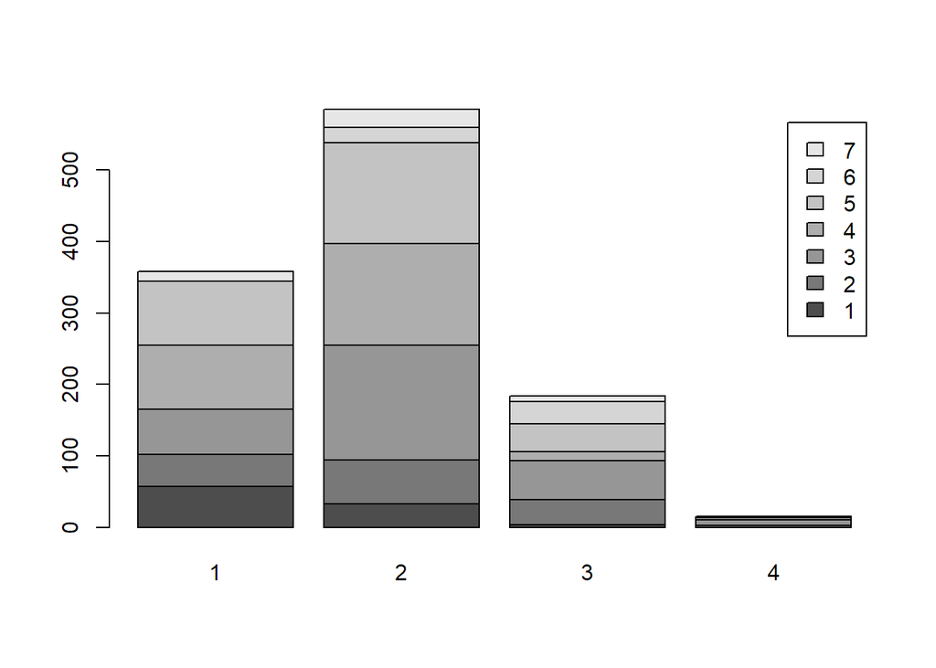

```r
barplot(TAB, legend = T)
```

```r
alpha <- 0.01

total <- sum(TAB)
sumRows <- margin.table(TAB, 1) #rows
sumCols <- margin.table(TAB,2) #columns

sumRows <- as.vector(sumRows)
sumCols <- as.vector(sumCols)

#expected observations
exp <- matrix(rep(0, 4*7), nrow=7, ncol=4)
exp[] <- 0L
for(i in 1:7) {
    exp[i, ] <- sumRows[i]*sumCols/total
}
#observations
#obs <- matrix(rep(0, 4*7), nrow=7, ncol=4)

Tab <- data.frame(TAB)
obs <- matrix(Tab[["Freq"]], nrow = 7, ncol = 4)

chi_sq <- sum((obs-exp)^2/exp) #test statistic
df <- (nrow(obs)-1)*(ncol(obs)-1) #deg of freedom
pval <- pchisq(chi_sq, df, lower.tail=FALSE)  #test of independence is always right-tailed because of the calculation of the test statistic

quantile <- qchisq(alpha, df, lower.tail = FALSE) #quantile of chi-square distribution

if(alpha > pval) {
  print("H0 rejected.")
}else {
  print("There is not enough evidence to suggest an association between RAM and company")
}
```

```
[1] "H0 rejected."
```

```r
sprintf("test statistic = %f , p-value = %f, confidece interval = [-infinity, %f]", chi_sq, pval, quantile)
```

```
[1] "test statistic = 164.234074 , p-value = 0.000000, confidece interval = [-infinity, 34.805306]"
```

```
test statistic = 164.234074 , p-value = 0.000000, confidece interval = [-infinity, 34.805306]
```

```r
#chisq.test()
test <- chisq.test(TAB)
test
```

```
    Pearson's Chi-squared test

data:  TAB
X-squared = 164.23, df = 18, p-value < 2.2e-16
```

Wychodzi, że **ilość pamięci RAM zależy od producenta** (wartość statystyki testowej wpada do obszaru krytycznego oraz p-value jest mniejsze niż nasz ustalony poziom istotności).

**b)** Rozkład stosowanych pamięci RAM w notebookach HP i Lenovo jest taki sam.

**Test istotności dla dwóch wariancji** sprawdza hipotezę, że próby pochodzą z populacji o jednakowych wariancjach.

Hipoteza zerowa $H_0$: Równe wariancje. Hipoteza alternatywna $H_1$: Różne wariancje

```r
alpha <- 0.1

#independent populations
LenovoRAM <- dataSet[dataSet$company=="5", ]$ram
HPRAM <- dataSet[dataSet$company=="4", ]$ram

n <- length(LenovoRAM)
m <- length(HPRAM)

#unbiased variance estimators
unbiased_estX <- 1/(n-1)*sum((LenovoRAM-mean(LenovoRAM))^2)
unbiased_estY <- 1/(m-1)*sum((HPRAM-mean(HPRAM))^2)

#fisher's test
F <- unbiased_estX/(unbiased_estY) # Snedecor's F distribution
pval <- pf(F, n-1, m-1, lower.tail = FALSE)
quantile <- qf(alpha, n-1, m-1, lower.tail = FALSE) #right-tailed

if(alpha > pval) {
  print("H0 rejected.")
}else {
  print("There is not enough evidence to reject H_0")
}
```

```
[1] "H0 rejected."
```

```r
sprintf("test statistic = %f , p-value = %f, confidece interval = [-infinity, %f]", F, pval, quantile)
```

```
[1] "test statistic = 1.518314 , p-value = 0.000456, confidece interval = [-infinity, 1.174316]"
```

```
test statistic = 1.518314 , p-value = 0.000456, confidece interval = [-infinity, 1.174316]
```

```r
#sprawdźmy
var.test(LenovoRAM, HPRAM, 1)
```

```
    F test to compare two variances

data:  LenovoRAM and HPRAM
F = 1.5183, num df = 271, denom df = 244, p-value = 0.0009113
alternative hypothesis: true ratio of variances is not equal to 1
95 percent confidence interval:
 1.187251 1.938597
sample estimates:
ratio of variances
          1.518314
```

**Odrzucamy hipotezę zerową** ponieważ wartość testu wpada do obszaru krytycznego / p-value jest mniejsze niż ustalony poziom istotności. **Rozkład stosowanych pamięci RAM w notebookach HP i Lenovo nie jest taki sam.**

**c)** Średnia zlogarytmowana cena notebooka Dell i HP jest równa.

**Independent two-sample t-test** wykorzystujemy, gdy chcemy porównać dwie grupy pod względem jakiejś zmiennej ilościowej.  
Hipoteza zerowa $H_0$: Średnia zlogarytmowana cena notebooka Dell jest taka sama jak średnia zlogarytmowana cena notebooka HP.  
Hipoteza alternatywna $H_1$: Średnie zlogarytmowane ceny notebooków różnią się.

```r
alpha <- 0.1

dellPrices <- dataSet[dataSet$company=="3", "price_euros"]
hpPrices <- dataSet[dataSet$company=="4", "price_euros"]

logDellPrices <- log2(dellPrices)
logHpPrices <- log2(hpPrices)

n <- length(dellPrices)
m <- length(hpPrices)

#checking assumption
assum <- var(logDellPrices) != var(logHpPrices)

#unbiased variance estimators
unbiased_estX <- 1/(n-1)*sum((logDellPrices-mean(logDellPrices))^2)
unbiased_estY <- 1/(m-1)*sum((logHpPrices-mean(logHpPrices))^2)

a <- unbiased_estX/n + unbiased_estY/m
t <- (mean(logDellPrices) - mean(logHpPrices))/sqrt(a) #test statistic

df <- a^2/(1/(n-1)*(unbiased_estX/n)^2+1/(m-1)*(unbiased_estY/m)^2) #deg of freedom

#two-tailed hypothesis
pval <- 2*pt(t, n+m-2, lower.tail = FALSE)

#confidence interval
lowerBound <- qt(alpha, n+m-2)
upperBound <- qt(1-alpha, n+m-2)

if(alpha > pval) {
  print("H0 rejected.")
}else {
  print("There is not enough evidence to reject H_0")
}
```

```
[1] "H0 rejected."
```

```r
sprintf("Spełnione założenia: %s, test statistic = %f , p-value=%f, confidence interval = (%f, %f)", assum, t, pval, lowerBound, upperBound)
```

```
[1] "Spełnione założenia: TRUE, test statistic = 2.185085 , p-value=0.029321, confidence interval = (-1.283157, 1.283157)"
```

```
Spełnione założenia: TRUE, test statistic = 2.185085 , p-value=0.029321, confidence interval = (-1.283157, 1.283157)
```

```r
#t.test
t.test(logDellPrices, logHpPrices)
```

```
    Welch Two Sample t-test

data:  logDellPrices and logHpPrices
t = 2.1851, df = 503.74, p-value = 0.02934
alternative hypothesis: true difference in means is not equal to 0
95 percent confidence interval:
 0.01507785 0.28388985
sample estimates:
mean of x mean of y
 10.03851   9.88903
```

**Odrzucamy hipotezę zerową** - wartość testu wpada do obszaru krytycznego/ p-value mniejsze niż ustalony poziom istotności - na rzecz hipppotezy alternatywnej. **Średnie zlogarytmowane ceny notebooków różnią się.**